# Encounter distribution analysis

Marie Gilbertson

2025-03-10

# Introduction

In this report, I’ll demonstrate the general workflow for our analysis of encounter distributions. Encounter distributions are described in [Noonan et al. 2021](https://doi.org/10.1111/2041-210X.13597) *Methods in Ecology and Evolution.* They represent a probability distribution for the locations at which individuals were most likely to have encountered each other. We calculated seasonal encounter distributions for pairs of deer, and then evaluated the habitat composition of these distributions. Our aim was to determine if some habitats were more favorable for encounters, depending on deer age, sex, and season.

To demonstrate our approach, I’ll start by loading the packages we’ll need. I also always set my seed as standard practice (this makes randomization reproducible).

```r
##### Clear Environment #####
remove(list=ls())


#### set seed ####
set.seed(4651)


#### load libraries ####
library(terra)
library(sf)
library(ctmm)
library(plyr)
library(dplyr)
library(ggplot2)
library(mgcv)
library(ggpubr)
```

## Encounter distribution estimation

The approach - including code - for estimating encounter distributions is thoroughly documented in [Noonan et al. 2021](https://doi.org/10.1111/2041-210X.13597). Furthermore, the methods are easily implemented in R with the *ctmm* package; in particular, the encounter() function. We therefore direct interested users to these resources; referring to the original sources is important for ensuring users understand the underlying methods before applying them to their own data. We also want to make sure Noonan et al. get proper credit for their excellent documentation! Nothing in our approach was novel, as we closely followed the code provided by Noonan et al.

## Extract land use within encounter distributions

We will proceed by demonstrating how to extract land use classifications from within an identified encounter distribution. First, let’s load an example encounter distribution:

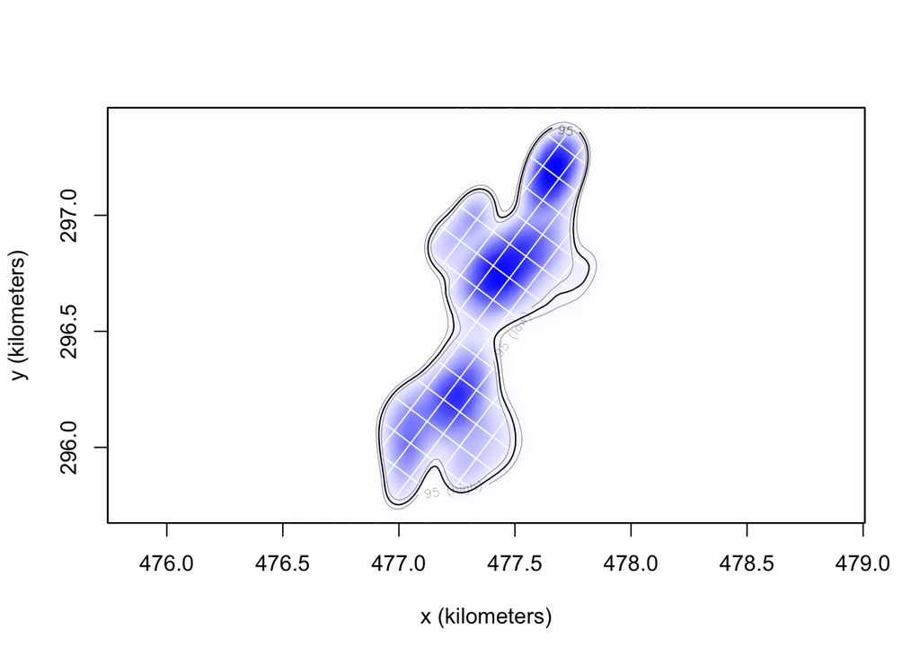

```r
## Example CDE
cde <- get(load("../Project_data/cdeout_5002_5833_2017_fa.Rdata"))
cde <- cde$CDE # object I originally created is a list, including data; we just want the encounter distribution (CDE) itself
plot(cde)
```

Let’s extract just the 95% isopleth from this encounter distribution.

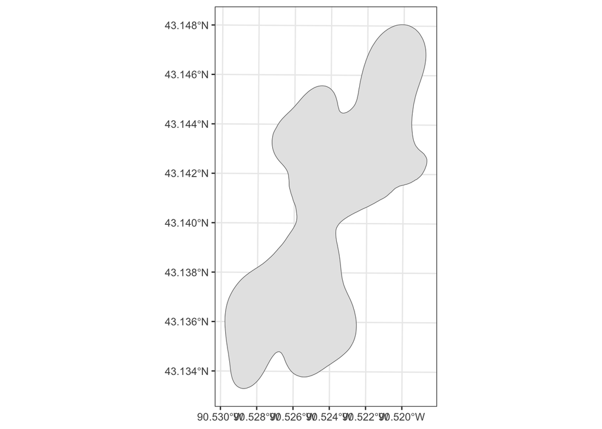

```r
vert <- SpatialPolygonsDataFrame.UD(cde, level.UD = 0.95, level = 0.95)
vert.e <- vert[2,] # extract estimate (rather than confidence intervals)
poly.sf <- st_as_sf(vert.e)

ggplot(poly.sf) +
  geom_sf() + theme_bw()
```

Now, let’s read in some static landscape data. We’ll use level-1 land use classifications from [Wiscland2](https://data-wi-dnr.opendata.arcgis.com/documents/wi-dnr::wiscland-2/about?path=). These are fairly coarse land use classifications (though we simplified even further in our manuscript), but give a relevant example of the workflow.

```r
wl <- rast("../Project_data/WiscLand2_level1.tif")
class(wl)
```

```
## [1] "SpatRaster"
## attr(,"package")
## [1] "terra"
```

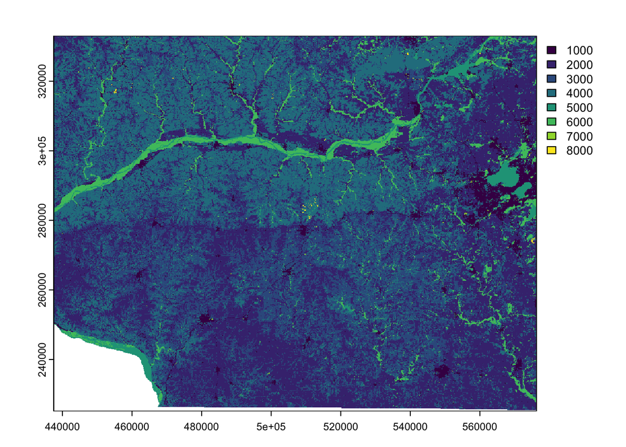

```r
terra::plot(wl)
```

I know that my land cover and movement data are in the same coordinate reference system (CRS). However, interested users should always ensure this with their own data, especially if they are downloading landscape data from different sources.

The area covered by our Wiscland2 habitat raster is very large. Let’s crop it down so we can see our encounter distribution polygon in context.

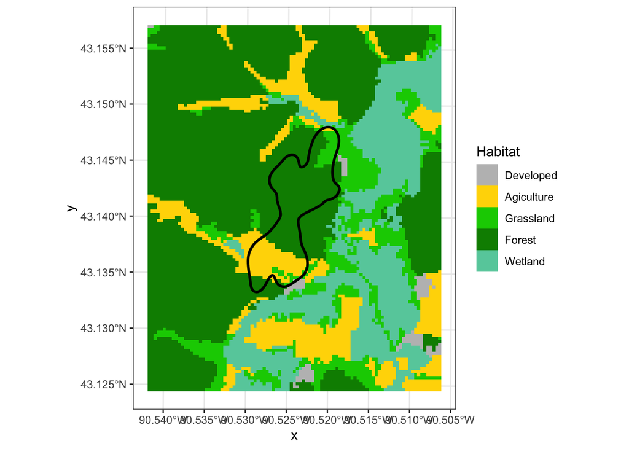

```r
wl.cde <- crop(wl, ext(buffer(vert.e, 1000)))

## we can plot to review
wl.df <- as.data.frame(wl.cde, xy = T)

ggplot() +
  theme_bw() + geom_raster(data = wl.df, aes(x = x, y = y, fill = as.factor(layer))) +
  scale_fill_manual(values = c("1000" = "grey", "2000" = "gold", "3000" = "green3", "4000" = "green4", "6000" = "aquamarine3"), name = "Habitat",
                    labels = c("Developed", "Agiculture", "Grassland", "Forest", "Wetland")) +
  geom_sf(data = poly.sf, fill = "transparent", colour = "black", linewidth = 1)
```

We can see that this encounter distribution is primarily composed of forest, agriculture, and grassland. Let’s go ahead and extract the habitat values within the encounter distribution.

```r
c <- extract(wl.cde, poly.sf, xy = T)
head(c)
```

```
##   ID layer      x        y
## 1  1  2000 477644 297363.8
## 2  1  2000 477674 297363.8
## 3  1  2000 477704 297363.8
## 4  1  2000 477734 297363.8
## 5  1  2000 477764 297363.8
## 6  1  4000 477614 297333.8
```

```r
nrow(c)
```

```
## [1] 748
```

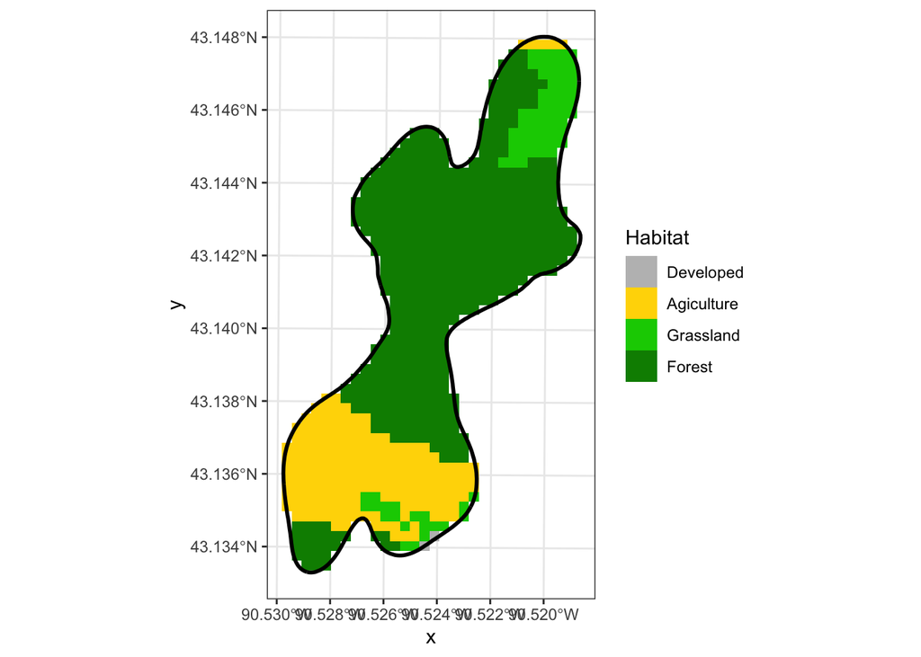

```r
## plot to check
ggplot() +
  theme_bw() + geom_raster(data = c, aes(x = x, y = y, fill = as.factor(layer))) +
  scale_fill_manual(values = c("1000" = "grey", "2000" = "gold", "3000" = "green3", "4000" = "green4", "6000" = "aquamarine3"), name = "Habitat",
                    labels = c("Developed", "Agiculture", "Grassland", "Forest", "Wetland")) +
  geom_sf(data = poly.sf, fill = "transparent", colour = "black", linewidth = 1)
```

The extract() function produces a data frame with the land use classification for each cell that falls within our polygon of interest. If we want to eventually model the proportions of different habitat types in encounter distributions, we can extract the counts and proportions here:

```r
counts <- data.frame(table(c$layer))
props <- data.frame(prop.table(table(c$layer)))

props
```

```
##   Var1        Freq
## 1 1000 0.002673797
## 2 2000 0.240641711
## 3 3000 0.101604278
## 4 4000 0.655080214
```

These proportions are what we can then use as response variables to determine how habitat in encounter distributions varies by season and deer sex.

## Spatial GAMs

We’ll now use our “proportion land use type” as a response variable in models aiming to determine how the habitat composition of encounter distributions varies with factors like deer sex and season. I’ll start by loading a full dataset; this dataset includes some information we don’t need, so I’ll extract just the relevant columns.

Some column names are self-explanatory, but others less so:

- X1/X2 = IDs of the two individuals that are part of a given encounter distribution
- sex.d = Sexes of the pair (FF, MF, or MM)
- age.diff = difference in ages of the pair (in integer years)
- cent.x/cent.y = x and y coordinates of the encounter distribution centroid
- ba = Bhattacharyya coefficient between the seasonal home ranges of the pair (quantifies home range overlap)
- area.km.95 = area of the 95% isopleth of the encounter distribution
- p.corn, etc = proportion of the encounter distribution classified as a given habitat type

```r
#### load data ####
cde <- get(load("../Project_data/spatial_models_rd3_082423.Rdata"))
cde <- cde[,c("X1", "X2", "year", "season", "sex.d", "age.diff", "cent.x", "cent.y", "ba", "area.km.95", "p.central.hardwoods", "p.corn", "p.grass.past", "p.hay", "p.oak", "p.other", "p.soybean")]
head(cde)
```

```
##     X1   X2 year season sex.d age.diff   cent.x   cent.y           ba
## 1 5000 5050 2017     fa    MF        4 506642.8 294538.4 2.125124e-01
## 2 5000 5726 2017     fa    FF        0 507157.5 295707.0 3.110565e-02
## 3 5002 5064 2017     fa    MF        1 477176.2 296697.1 2.306478e-01
## 4 5002 5072 2017     fa    MF        7 477283.4 297082.1 6.078361e-01
## 6 5002 5833 2017     fa    MM        0 477372.9 296544.2 2.701245e-01
## 7 5002 5850 2017     fa    MM        0 477807.3 295677.7 1.582555e-06
##   area.km.95 p.central.hardwoods      p.corn p.grass.past       p.hay
## 1 0.86086276           0.5193717 0.046073298   0.26387435 0.025130890
## 2 0.16430473           0.6120219 0.038251366   0.24590164 0.021857923
## 3 0.35340312           0.4252577 0.005154639   0.00257732 0.000000000
## 4 0.35643634           0.3140704 0.042713568   0.03015075 0.000000000
## 6 0.67300532           0.2887701 0.133689840   0.10962567 0.004010695
## 7 0.03439476           0.0000000 0.078947368   0.42105263 0.236842105
##        p.oak     p.other   p.soybean
## 1 0.13612565 0.009424084 0.000000000
## 2 0.08196721 0.000000000 0.000000000
## 3 0.08762887 0.422680412 0.056701031
## 4 0.07286432 0.532663317 0.007537688
## 6 0.04545455 0.332887701 0.085561497
## 7 0.00000000 0.263157895 0.000000000
```

We expect there to be some spatial autocorrelation in the composition of encounter distributions. Encounter distributions that are close to each other (e.g., because one individual is part of multiple encounter distributions) are more likely to have similar habitat compositions than those that are far apart. We therefore need to fit models that can account for this spatial autocorrelation. In the manuscript for this work, we used spatial Generalized Additive Models (GAMs). I’m going to walk through fitting GAMs for one of our habitat types: agricultural land use. We’ll have to combine a few agricultural land use classes into one “coarse” agriculture class. Let’s do this and take a look at the resulting data:

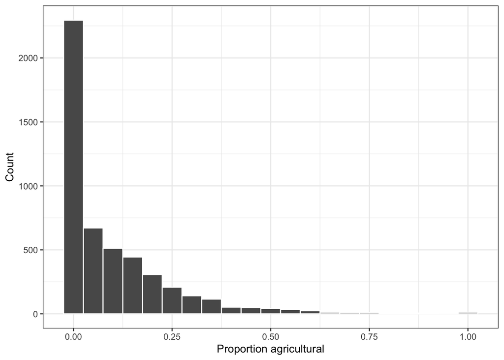

```r
cde$p.ag <- cde$p.corn + cde$p.hay + cde$p.soybean

ggplot(cde, aes(x = p.ag)) +
  geom_histogram(colour = "white", binwidth = 0.05) +
  xlab("Proportion agricultural") + ylab("Count") +
  theme_bw()
```

We can see that we have quite a lot of encounter distributions that entirely lack agricultural land use - even when we combine corn, hay, and soybeans into one class. Our data is “zero inflated,” and this can make it a challenge to fit some statistical models. Our approach in the manuscript was to model our data in two parts: a binary presence/absence part, and a continuous proportion part (given presence).

In addition, we found that our models performed better when we excluded encounter distributions where there was very little home range overlap between the pair, as quantified by the Bhattacharyya coefficient. Let’s go ahead and exclude encounter distributions with a Bhattacharyya coefficient ≤ 0.1, and create a new binary “is agricultural land use present or not” column.

```r
# select individuals based on BA threshold
cde.ba <- cde[cde$ba>0.1,]


# binary responses for ag and grass/pasture
cde.ba$ag.bin <- ifelse(cde.ba$p.ag>0, 1, 0)
```

Before we fit our models, we need to do a little bit more data wrangling. We’ll re-adjust the levels of our seasons and remove individuals with missing data. We’ll scale and center our continuous predictor (age difference). We also need to rescale our centroids - these will feature in our model, and their large values can make models do funky things.

```r
# adjust the order of the seasons
cde.ba$season <- factor(cde.ba$season, levels = c("fa", "pf", "br", "nb"))

# remove individuals missing ages
cde.ba <- cde.ba[!is.na(cde.ba$age.diff),]

# scale and center ages
cde.ba$age.diff.sc <- scale(cde.ba$age.diff)


# re-scale centroid coordinates
cde.ba$x <- cde.ba$cent.x/(10e4)
cde.ba$y <- cde.ba$cent.y/(10e4)
```

Next, we’ll split our data into training and testing data. We’ll fit our two models (binary and continuous) to the training data, and then review our model performance with the test data.

```r
# training versus testing datasets
set.seed(250) # for reproducibility
training.ids <- sample(1:nrow(cde.ba), size = floor(0.9*nrow(cde.ba)), replace = F) # 90% training
test.ids <- seq(1:nrow(cde.ba))[!seq(1:nrow(cde.ba)) %in% training.ids] # remaining 10% for testing

test <- cde.ba[test.ids,]
train <- cde.ba[training.ids,]
```

Now that we have our data all set up, we can start by fitting our first GAM. We’ll do the binary model first. This will use all the data in our training set, and the response variable is 0/1 for absence or presence of agriculture in encounter distributions, respectively. We account for spatial patterns in the data with the s() term in the model. The gam.check() function gives us some info for checking our model, and is part of how we arrived at the number of knots (k = 150, here) we used. Our k value may still be too low, but our other model checking and predictions looked ok, with diminishing returns for increasing k.

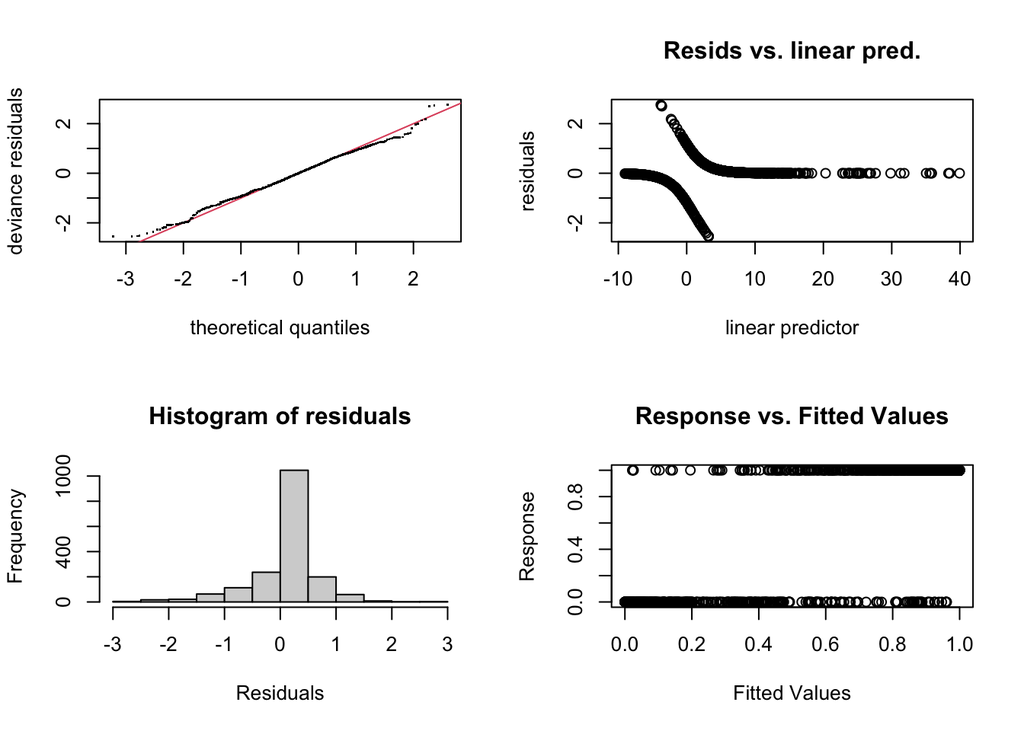

```
##
## Method: REML   Optimizer: outer newton
## full convergence after 4 iterations.
## Gradient range [2.554636e-06,2.554636e-06]
## (score 508.2535 & scale 1).
## Hessian positive definite, eigenvalue range [8.850907,8.850907].
## Model rank =  156 / 156
##
## Basis dimension (k) checking results. Low p-value (k-index<1) may
## indicate that k is too low, especially if edf is close to k'.
##
##           k'   edf k-index p-value
## s(x,y) 149.0  80.5     0.9  <2e-16 ***
## ---
## Signif. codes:  0 '***' 0.001 '**' 0.01 '*' 0.05 '.' 0.1 ' ' 1
```

```r
### Binary spatial GAM
tal <- gam(ag.bin ~ season + sex.d + age.diff.sc + s(x, y, bs="gp", k =150), family = binomial(link = "logit"), data = train, method = "REML")
par(mfrow = c(2,2))
gam.check(tal)
```

```r
par(mfrow = c(1,1))
summary(tal)
```

```
##
## Family: binomial
## Link function: logit
##
## Formula:
## ag.bin ~ season + sex.d + age.diff.sc + s(x, y, bs = "gp", k = 150)
##
## Parametric coefficients:
##             Estimate Std. Error z value Pr(>|z|)
## (Intercept)   2.2096     0.5819   3.797 0.000146 ***
## seasonpf      1.3627     0.2582   5.277 1.31e-07 ***
## seasonbr      1.8605     0.3084   6.032 1.62e-09 ***
## seasonnb      3.8289     0.5995   6.387 1.69e-10 ***
## sex.dMF       0.6094     0.2301   2.648 0.008090 **
## sex.dMM       1.4273     0.4578   3.118 0.001822 **
## age.diff.sc  -0.1844     0.1125  -1.640 0.101000
## ---
## Signif. codes:  0 '***' 0.001 '**' 0.01 '*' 0.05 '.' 0.1 ' ' 1
##
## Approximate significance of smooth terms:
##          edf Ref.df Chi.sq p-value
## s(x,y) 80.53   93.9  331.7  <2e-16 ***
## ---
## Signif. codes:  0 '***' 0.001 '**' 0.01 '*' 0.05 '.' 0.1 ' ' 1
##
## R-sq.(adj) =  0.708   Deviance explained = 68.8%
## -REML = 508.25  Scale est. = 1         n = 1771
```

```r
tal.table <- data.frame(summary(tal)$p.table) # store in a table
```

Similarly, we can now fit our continuous model. We’ll extract just the encounter distiributions where agriculture was present, and then use the proportion agriculture as the response variable.

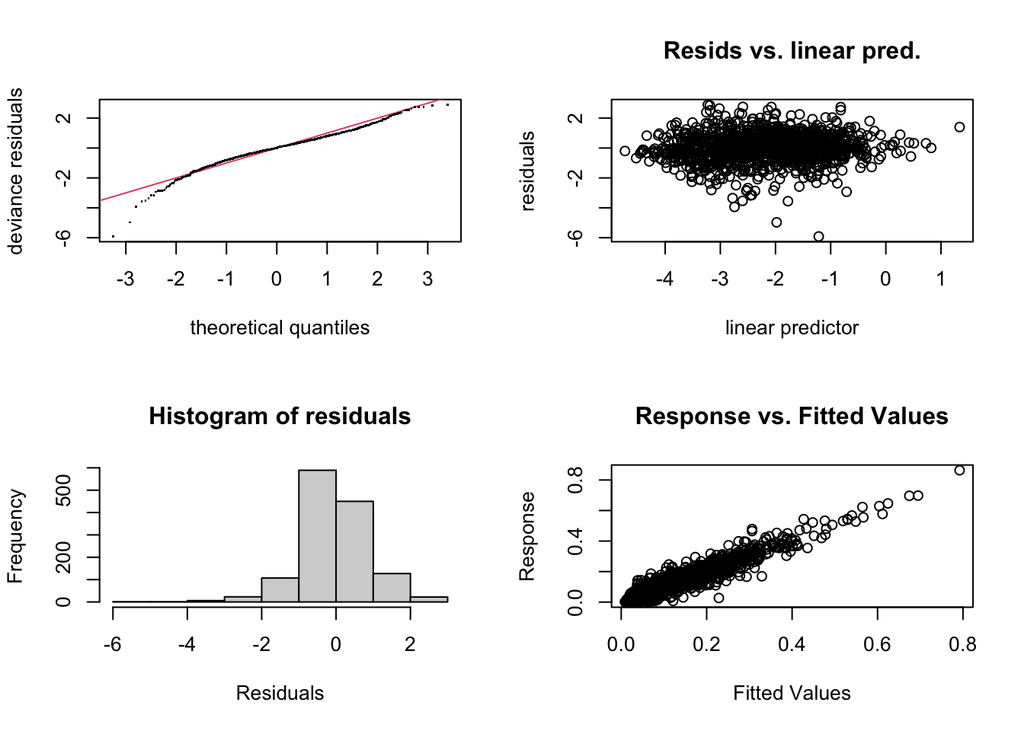

```
##
## Method: REML   Optimizer: outer newton
## full convergence after 5 iterations.
## Gradient range [0.0002232361,0.0007829313]
## (score -2160.064 & scale 1).
## Hessian positive definite, eigenvalue range [45.96285,527.7898].
## Model rank =  256 / 256
##
## Basis dimension (k) checking results. Low p-value (k-index<1) may
## indicate that k is too low, especially if edf is close to k'.
##
##         k' edf k-index p-value
## s(x,y) 249 189    1.01    0.55
```

```r
ag.cont <- train[train$p.ag>0,]
tga <- gam(p.ag ~ season + sex.d + age.diff.sc + s(x, y, bs="gp", k = 250), family = betar(link="logit"), data = ag.cont, method = "REML")
par(mfrow = c(2,2))
gam.check(tga)
```

```r
par(mfrow = c(1,1))
summary(tga)
```

```
##
## Family: Beta regression(59.607)
## Link function: logit
##
## Formula:
## p.ag ~ season + sex.d + age.diff.sc + s(x, y, bs = "gp", k = 250)
##
## Parametric coefficients:
##               Estimate Std. Error z value Pr(>|z|)
## (Intercept) -2.3252829  0.0259388 -89.645  < 2e-16 ***
## seasonpf     0.4270593  0.0304334  14.033  < 2e-16 ***
## seasonbr     0.1790119  0.0359408   4.981 6.33e-07 ***
## seasonnb     0.1361274  0.0495107   2.749  0.00597 **
## sex.dMF     -0.0715348  0.0294329  -2.430  0.01508 *
## sex.dMM     -0.0032688  0.0521872  -0.063  0.95006
## age.diff.sc -0.0004099  0.0138576  -0.030  0.97640
## ---
## Signif. codes:  0 '***' 0.001 '**' 0.01 '*' 0.05 '.' 0.1 ' ' 1
##
## Approximate significance of smooth terms:
##          edf Ref.df Chi.sq p-value
## s(x,y) 188.8  216.9   6375  <2e-16 ***
## ---
## Signif. codes:  0 '***' 0.001 '**' 0.01 '*' 0.05 '.' 0.1 ' ' 1
##
## R-sq.(adj) =  0.888   Deviance explained = 89.8%
## -REML = -2160.1  Scale est. = 1         n = 1326
```

```r
tga.table <- data.frame(summary(tga)$p.table) # store in a table
```

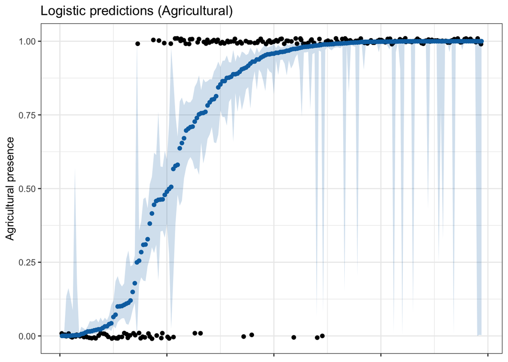

```r
## Binary presence/absence predictions
agbin.predictions <- predict(tal, type = "link", newdata = test, se.fit = T)
test$agbin.predictions <- plogis(agbin.predictions$fit)
test$low <- plogis(agbin.predictions$fit - agbin.predictions$se.fit) # confidence intervals
test$high <- plogis(agbin.predictions$fit + agbin.predictions$se.fit)

test <- test[order(test$agbin.predictions),] # order the predictions for visualization purposes
test$seq <- seq(1, nrow(test))

ggplot(test) +
  geom_jitter(aes(x = seq, y = ag.bin), height = 0.01) +
 geom_point(aes(x = seq, y = agbin.predictions), colour = "#0571b0") +
  geom_ribbon(aes(x = seq, ymin = low, ymax = high), alpha = 0.2, fill = "#0571b0") +
  ylab("Agricultural presence") +
  ggtitle("Logistic predictions (Agricultural)") +
  theme_bw() +
  theme(axis.title.x = element_blank(), axis.text.x = element_blank())
```

Our model seems to do reasonably well at predicting presence/absence of agricultural land use in encounter distributions. How about the proportion of agriculture, given that agriculture is present?

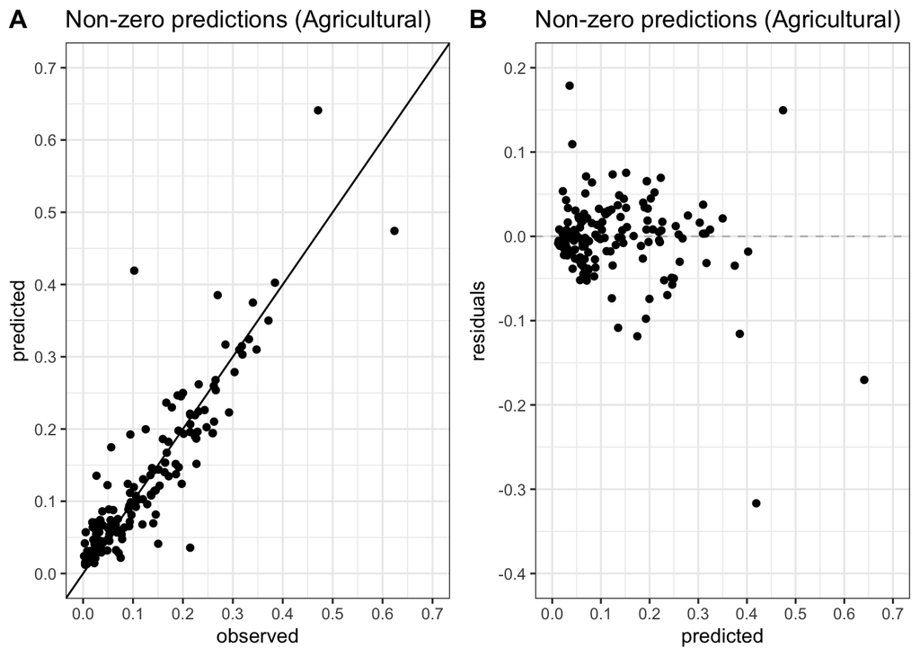

```r
test.nz <- test[test$p.ag>0,]
agnz.predictions <- predict(tga, type = "link", newdata = test.nz, se.fit = T)
test.nz$agnz.predictions <- plogis(agnz.predictions$fit)
test.nz$low <- plogis(agnz.predictions$fit - agnz.predictions$se.fit) # confidence intervals
test.nz$high <- plogis(agnz.predictions$fit + agnz.predictions$se.fit)

test.nz$pred.resid <- test.nz$p.ag - test.nz$agnz.predictions # residuals

## observed vs predicted
px <- pretty(test.nz$p.ag) # get nice axis breaks
py <- pretty(test.nz$agnz.predictions)
pag1 <- ggplot(test.nz, aes(x = p.ag, y = agnz.predictions)) +
  geom_abline(slope = 1) +
  geom_point() +
  xlab("observed") + ylab("predicted") +
  scale_x_continuous(limits = range(px), breaks = px) +
  scale_y_continuous(limits = range(py), breaks = py) +
  ggtitle("Non-zero predictions (Agricultural)") +
  theme_bw()

## predicted vs residuals
px <- pretty(test.nz$agnz.predictions)
py <- pretty(test.nz$pred.resid)
pag2 <- ggplot(test.nz, aes(x = agnz.predictions, y = pred.resid)) +
  geom_hline(yintercept = 0, color = "grey", linetype = "dashed") +
  geom_point() +
  xlab("predicted") + ylab("residuals") +
  scale_x_continuous(limits = range(px), breaks = px) +
  scale_y_continuous(limits = range(py), breaks = py) +
  ggtitle("Non-zero predictions (Agricultural)") +
  theme_bw()


ggarrange(pag1, pag2, labels = c("A", "B"))
```

Our continuous predictions look fairly reasonable, especially as compared to when using the full dataset (not shown here, but see the supplementary materials for the manuscript).

We repeat this same process for our other habitat classifications (forest and grass/pasture). And that’s it!

## Wrap up

I didn’t show fitting models with different Bhattacharyya coefficient cut-offs, but the process is identical. Results of these models are given in the accompanying manuscript’s supplementary materials, and clearly show reduced predictive performance when using lower cut-offs.